# Analyzing TIMDB (The Indian Movie Database)

**The complete database can be found on [Github](https://github.com/pncnmnp/TIMDB).**

**This notebook is created by the author of this dataset.**

This database contains a list of Indian movies and it's meta-data, with release years ranging between 1950 and 2019. As the database is big, we will start by analyzing the primary dataset: `./1950-2019/bollywood_full.csv`

```python
import pandas as pd
import numpy as np
import matplotlib.pyplot as plt
import seaborn as sns
from mpl_toolkits.mplot3d import Axes3D
from sklearn.feature_extraction.text import CountVectorizer
from sklearn.metrics.pairwise import cosine_similarity
from nltk.corpus import stopwords
from difflib import get_close_matches
from surprise import Reader, Dataset, KNNBaseline

file = "./1950-2019/bollywood_full.csv"
df = pd.read_csv(open(file, "r"))
```

## Initial Analysis

```python
df.head()
```

|  | title_x | imdb_id | poster_path | wiki_link | title_y | original_title | is_adult | year_of_release | runtime | genres | imdb_rating | imdb_votes | story | summary | tagline | actors | wins_nominations | release_date |
| --- | --- | --- | --- | --- | --- | --- | --- | --- | --- | --- | --- | --- | --- | --- | --- | --- | --- | --- |
| 0 | Uri: The Surgical Strike | tt8291224 | https://upload.wikimedia.org/wikipedia/en/thum... | https://en.wikipedia.org/wiki/Uri:_The_Surgica... | Uri: The Surgical Strike | Uri: The Surgical Strike | 0 | 2019 | 138 | Action\|Drama\|War | 8.4 | 35112.0 | Divided over five chapters the film chronicle... | Indian army special forces execute a covert op... | NaN | Vicky Kaushal\|Paresh Rawal\|Mohit Raina\|Yami Ga... | 4 wins | 11 January 2019 (USA) |
| 1 | Battalion 609 | tt9472208 | NaN | https://en.wikipedia.org/wiki/Battalion_609 | Battalion 609 | Battalion 609 | 0 | 2019 | 131 | War | 4.1 | 73.0 | The story revolves around a cricket match betw... | The story of Battalion 609 revolves around a c... | NaN | Vicky Ahuja\|Shoaib Ibrahim\|Shrikant Kamat\|Elen... | NaN | 11 January 2019 (India) |
| 2 | The Accidental Prime Minister (film) | tt6986710 | https://upload.wikimedia.org/wikipedia/en/thum... | https://en.wikipedia.org/wiki/The_Accidental_P... | The Accidental Prime Minister | The Accidental Prime Minister | 0 | 2019 | 112 | Biography\|Drama | 6.1 | 5549.0 | Based on the memoir by Indian policy analyst S... | Explores Manmohan Singh's tenure as the Prime ... | NaN | Anupam Kher\|Akshaye Khanna\|Aahana Kumra\|Atul S... | NaN | 11 January 2019 (USA) |
| 3 | Why Cheat India | tt8108208 | https://upload.wikimedia.org/wikipedia/en/thum... | https://en.wikipedia.org/wiki/Why_Cheat_India | Why Cheat India | Why Cheat India | 0 | 2019 | 121 | Crime\|Drama | 6.0 | 1891.0 | The movie focuses on existing malpractices in ... | The movie focuses on existing malpractices in ... | NaN | Emraan Hashmi\|Shreya Dhanwanthary\|Snighdadeep ... | NaN | 18 January 2019 (USA) |
| 4 | Evening Shadows | tt6028796 | NaN | https://en.wikipedia.org/wiki/Evening_Shadows | Evening Shadows | Evening Shadows | 0 | 2018 | 102 | Drama | 7.3 | 280.0 | While gay rights and marriage equality has bee... | Under the 'Evening Shadows' truth often plays... | NaN | Mona Ambegaonkar\|Ananth Narayan Mahadevan\|Deva... | 17 wins & 1 nomination | 11 January 2019 (India) |

```python
df.describe(include="all")
```

|  | title_x | imdb_id | poster_path | wiki_link | title_y | original_title | is_adult | year_of_release | runtime | genres | imdb_rating | imdb_votes | story | summary | tagline | actors | wins_nominations | release_date |
| --- | --- | --- | --- | --- | --- | --- | --- | --- | --- | --- | --- | --- | --- | --- | --- | --- | --- | --- |
| count | 4330 | 4330 | 3580 | 4330 | 4330 | 4330 | 4330.0 | 4330 | 4330 | 4330 | 4317.000000 | 4317.000000 | 4065 | 4329 | 685 | 4320 | 1344 | 3049 |
| unique | 4288 | 4284 | 3529 | 4330 | 4052 | 4047 | NaN | 71 | 149 | 264 | NaN | NaN | 4020 | 4021 | 678 | 4271 | 250 | 2278 |
| top | Aan | tt0347416 | https://upload.wikimedia.org/wikipedia/en/thum... | https://en.wikipedia.org/wiki/Aakraman | Anari | Dushman | NaN | 2014 | \N | Drama | NaN | NaN | A Royal Indian family consists of the Emperor ... | Add a Plot » | A million-dollar fake | Mala Sinha\|Dharmendra\|Kumkum\|Sujit Kumar\|Mehmo... | 1 nomination | 1977 (India) |
| freq | 2 | 2 | 7 | 1 | 4 | 4 | NaN | 110 | 919 | 513 | NaN | NaN | 2 | 264 | 2 | 2 | 229 | 8 |
| mean | NaN | NaN | NaN | NaN | NaN | NaN | 0.0 | NaN | NaN | NaN | 5.911744 | 2387.874913 | NaN | NaN | NaN | NaN | NaN | NaN |
| std | NaN | NaN | NaN | NaN | NaN | NaN | 0.0 | NaN | NaN | NaN | 1.330077 | 9404.126400 | NaN | NaN | NaN | NaN | NaN | NaN |
| min | NaN | NaN | NaN | NaN | NaN | NaN | 0.0 | NaN | NaN | NaN | 0.000000 | 0.000000 | NaN | NaN | NaN | NaN | NaN | NaN |
| 25% | NaN | NaN | NaN | NaN | NaN | NaN | 0.0 | NaN | NaN | NaN | 5.100000 | 32.000000 | NaN | NaN | NaN | NaN | NaN | NaN |
| 50% | NaN | NaN | NaN | NaN | NaN | NaN | 0.0 | NaN | NaN | NaN | 6.100000 | 131.000000 | NaN | NaN | NaN | NaN | NaN | NaN |
| 75% | NaN | NaN | NaN | NaN | NaN | NaN | 0.0 | NaN | NaN | NaN | 6.900000 | 966.000000 | NaN | NaN | NaN | NaN | NaN | NaN |
| max | NaN | NaN | NaN | NaN | NaN | NaN | 0.0 | NaN | NaN | NaN | 9.400000 | 310481.000000 | NaN | NaN | NaN | NaN | NaN | NaN |

```python
df.shape
```

```
(4330, 18)
```

Looking at the above information, few elementary conclusions can be drawn:

- There are 4330 movies in this dataset
- As mean is `0.0` for `is_adult`, the value is same for all movies. Hence we can drop that attribute
- `actors` and `genres` are separated by |
- Many movies don't have information about `tagline` and `wins_nominations` (Less information pertaining to `wins_nominations` is obvious as not every film can win awards or get nominated 😄)
- `runtime` is of dtype `object` as null values are entered in character form ('\N'). We need to convert it to `float64` type
- The mean IMDB rating is 5.91 and the maximum rating a film has been given is 9.4

**A note from documentation (for `./1950-2019/bollywood_full.csv`)**

> (This dataset is merged ON "imdb_id", hence if you find a niche-movie missing, see the respective year's directory).

**i.e** if a movie released in 1994 is missing from this dataset, check the directory `./1990-2009/`

```python
df = df.drop(['is_adult'], axis=1)

df["actors"] = df["actors"].apply(lambda actors: actors.strip().split("|") if isinstance(actors, str) else [])
df["genres"] = df["genres"].apply(lambda genres: genres.strip().split("|") if isinstance(genres, str) else [])

df["runtime"] = pd.to_numeric(df["runtime"].replace("\\N", np.nan))
```

```python
df["runtime"].dtype
```

```
dtype('float64')
```

```python
df[["actors", "genres"]].head()
```

|  | actors | genres |
| --- | --- | --- |
| 0 | [Vicky Kaushal, Paresh Rawal, Mohit Raina, Yam... | [Action, Drama, War] |
| 1 | [Vicky Ahuja, Shoaib Ibrahim, Shrikant Kamat, ... | [War] |
| 2 | [Anupam Kher, Akshaye Khanna, Aahana Kumra, At... | [Biography, Drama] |
| 3 | [Emraan Hashmi, Shreya Dhanwanthary, Snighdade... | [Crime, Drama] |
| 4 | [Mona Ambegaonkar, Ananth Narayan Mahadevan, D... | [Drama] |

Before we continue, I have got to know *which film scored a 9.4 on IMDB* 😁

```python
df[df["imdb_rating"] == 9.4][["original_title", "year_of_release", "imdb_id"]]
```

|  | original_title | year_of_release | imdb_id |
| --- | --- | --- | --- |
| 41 | Family of Thakurganj | 2019 | tt8897986 |

How ? What .... [Apparently this film does have a rating of 9.4](https://www.imdb.com/title/tt8897986/)! (as of December 27, 2019)

Let's start playing with the dataset. First we will find statistics about `runtime` attribute.

```python
(df["runtime"].describe(), "Total hours of content created by Indian cinema: " + str(sum(df["runtime"].dropna().tolist())/60))
```

```
(count    3411.000000
 mean      140.250660
 std        23.763995
 min         7.000000
 25%       126.000000
 50%       140.000000
 75%       155.000000
 max       321.000000
 Name: runtime, dtype: float64,
 'Total hours of content created by Indian cinema: 7973.25')
```

As we can see, **the average runtime of a Bollywood movie is around `140` minutes**.

Also `7973` hours (approx.) of content has been produced by Indian Cinema. *That's impressive!*

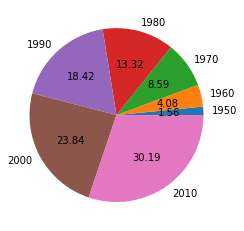

```python
year_mapping = dict()
for year in range(1950, 2020, 10):
    year_mapping[year] = 0
    for key in df["year_of_release"].dropna().value_counts().keys():
        if key != "\\N" and int(key) - year < 10:
            year_mapping[year] += df["year_of_release"].dropna().value_counts()[key]

plt.pie([val for val in year_mapping.values()], labels=[key for key in year_mapping.keys()], autopct="%.2f")
plt.plot()
plt.show()
```

The above pie chart shows the % of movies released (categorized by decade). Almost 75% of all movies were released in the last 3 decades. The film industry saw an approx. of 5% growth every decade!

We will now look at the blockbusters produced by Indian cinema. For this, I will be using IMDB's rating algorithm:

> weighted rating (WR) = (v ÷ (v+m)) × R + (m ÷ (v+m)) × C  
> Where:  
> R = average for the movie (mean) = (rating)  
> v = number of votes for the movie = (votes)  
> m = minimum votes required to be listed in the Top Rated list (currently 25,000)  
> C = the mean vote across the whole report

All the genres in the dataset are:

```python
all_genres = set([genre for genre in [genres for genres in df["genres"].tolist()] for genre in genre])
all_genres.remove("\\N")
all_genres
```

```
{'Action',
 'Adventure',
 'Animation',
 'Biography',
 'Comedy',
 'Crime',
 'Documentary',
 'Drama',
 'Family',
 'Fantasy',
 'History',
 'Horror',
 'Music',
 'Musical',
 'Mystery',
 'Romance',
 'Sci-Fi',
 'Short',
 'Sport',
 'Thriller',
 'War',
 'Western'}
```

```python
def imdb_rating(film, C, m):
    vote = film["imdb_votes"]
    rating = film["imdb_rating"]

    return ((vote / (vote + m)) * rating) + ((m / (vote + m)) * C)
```

```python
def top_movies(df, percentile=0.85, limit=10, offset=0, genre=None):
    if genre != None:
        top_df = df[df["genres"].apply(lambda genres: genre in genres)]
    else:
        top_df = df

    rating = df[df["imdb_rating"].notnull()]["imdb_rating"]
    votes = df[df["imdb_votes"].notnull()]["imdb_votes"]
    imdb_C = rating.mean()
    # For the dataset, percentile = 0.85 roughly corresponds to 2500
    # To match IMDB's parameter, percentile should be around 0.98026
    imdb_m = votes.quantile(percentile)

    top_df = top_df[top_df["imdb_votes"] >= imdb_m]

    pd.options.mode.chained_assignment = None
    top_df["rating"] = top_df.apply(imdb_rating, args=(imdb_C, imdb_m), axis=1)
    top_df = top_df.sort_values("rating", ascending=False)

    return top_df.iloc[offset: offset+limit]
```

```python
top_movies(df)[["original_title", "imdb_rating", "imdb_votes", "rating", "year_of_release", "imdb_id"]]
```

|  | original_title | imdb_rating | imdb_votes | rating | year_of_release | imdb_id |
| --- | --- | --- | --- | --- | --- | --- |
| 3615 | Anand | 8.8 | 23953.0 | 8.527217 | 1971 | tt0066763 |
| 916 | 3 Idiots | 8.4 | 310481.0 | 8.380139 | 2009 | tt1187043 |
| 1131 | Taare Zameen Par | 8.4 | 148498.0 | 8.358832 | 2007 | tt0986264 |
| 354 | Dangal | 8.4 | 131338.0 | 8.353554 | 2016 | tt5074352 |
| 146 | Andhadhun | 8.4 | 51615.0 | 8.285127 | 2018 | tt8108198 |
| 3119 | Gol Maal | 8.6 | 16086.0 | 8.238628 | 1979 | tt0079221 |
| 0 | Uri: The Surgical Strike | 8.4 | 35112.0 | 8.234721 | 2019 | tt8291224 |
| 1209 | Bacheha-Ye aseman | 8.3 | 56293.0 | 8.198516 | 1997 | tt0118849 |
| 1062 | Black Friday | 8.5 | 16761.0 | 8.164265 | 2004 | tt0400234 |
| 1201 | Rang De Basanti | 8.2 | 103071.0 | 8.145850 | 2006 | tt0405508 |

To find top movies (by genre), simply fill the `genre` attribute

```python
top_movies(df, genre="Mystery")[["original_title", "imdb_rating", "imdb_votes", "rating", "year_of_release", "imdb_id"]]
```

|  | original_title | imdb_rating | imdb_votes | rating | year_of_release | imdb_id |
| --- | --- | --- | --- | --- | --- | --- |
| 426 | Drishyam | 8.2 | 58340.0 | 8.106037 | 2015 | tt4430212 |
| 436 | Talvar | 8.2 | 26612.0 | 8.003625 | 2015 | tt4934950 |
| 673 | Kahaani | 8.1 | 53181.0 | 8.001818 | 2012 | tt1821480 |
| 568 | Ugly | 8.1 | 17483.0 | 7.826408 | 2013 | tt2882328 |
| 15 | Badla | 7.9 | 15499.0 | 7.624009 | 2019 | tt8130968 |
| 1095 | Johnny Gaddaar | 7.8 | 10612.0 | 7.440185 | 2007 | tt1077248 |
| 393 | Detective Byomkesh Bakshy! | 7.6 | 14674.0 | 7.354394 | 2015 | tt3447364 |
| 27 | The Tashkent Files | 8.0 | 5524.0 | 7.349695 | 2019 | tt8108268 |
| 983 | Ghajini | 7.3 | 53086.0 | 7.237606 | 2008 | tt1166100 |
| 1103 | Manorama Six Feet Under | 7.7 | 6013.0 | 7.175113 | 2007 | tt0920464 |

You can get the *next 10 films* of the above list by simply changing the `offset` value!

```python
top_movies(df, genre="Mystery", offset=10)[["original_title", "imdb_rating", "imdb_votes", "rating", "year_of_release", "imdb_id"]]
```

|  | original_title | imdb_rating | imdb_votes | rating | year_of_release | imdb_id |
| --- | --- | --- | --- | --- | --- | --- |
| 731 | Talaash | 7.2 | 36801.0 | 7.118107 | 2012 | tt1787988 |
| 1350 | Ek Hasina Thi | 7.6 | 6000.0 | 7.103707 | 2004 | tt0352314 |
| 1056 | Bhool Bhulaiyaa | 7.2 | 19469.0 | 7.053494 | 2007 | tt0995031 |
| 1729 | Kaun? | 7.8 | 3071.0 | 6.952977 | 1999 | tt0195002 |
| 296 | Te3n | 7.2 | 10451.0 | 6.951466 | 2016 | tt4814290 |
| 376 | Rahasya | 7.6 | 3950.0 | 6.945926 | 2015 | tt3337550 |
| 691 | Shanghai | 7.2 | 9143.0 | 6.923540 | 2012 | tt2072227 |
| 1114 | No Smoking | 7.2 | 5817.0 | 6.812959 | 2007 | tt0995740 |
| 835 | Karthik Calling Karthik | 7.0 | 9451.0 | 6.772480 | 2010 | tt1373156 |
| 1417 | Bhoot | 6.5 | 3017.0 | 6.233540 | 2003 | tt0341266 |

Let us now find the top writers and directors of all time. We will be needing 3 new datasets!

```python
crew_movie_path = "./1950-2019/bollywood_crew.csv"
director_path = "./1950-2019/bollywood_crew_data.csv"
writer_path = "./1950-2019/bollywood_writers_data.csv"

crew_df = pd.read_csv(open(crew_movie_path))
director_df = pd.read_csv(open(director_path))
writer_df = pd.read_csv(open(writer_path))

crew_df.head()
```

|  | imdb_id | directors | writers |
| --- | --- | --- | --- |
| 0 | tt0042184 | nm0025608 | nm0025608\|nm0324690 |
| 1 | tt0042207 | nm0490178 | nm0161032\|nm1879927 |
| 2 | tt0042225 | nm0707533 | \N |
| 3 | tt0042233 | nm0788880 | nm0592578\|nm0788880 |
| 4 | tt0042380 | nm0439074 | nm1278450\|nm0438022\|nm1301772 |

```python
director_df.head()
```

|  | crew_id | name | born_year | death_year | profession | known_for |
| --- | --- | --- | --- | --- | --- | --- |
| 0 | nm0001408 | Shekhar Kapur | 1945 | \N | actor\|director\|producer | tt0240510\|tt0414055\|tt0109206\|tt0127536 |
| 1 | nm0002172 | Mukul Anand | 1951 | 1997 | director\|writer\|producer | tt0104607\|tt0102201\|tt0098999\|tt0092026 |
| 2 | nm0002411 | Mani Kaul | 1944 | 2011 | director\|writer\|actor | tt0207626\|tt0066514\|tt0070009\|tt0102515 |
| 3 | nm0003939 | Vikramaditya Motwane | 1976 | \N | producer\|writer\|director | tt0238936\|tt3322420\|tt1639426\|tt1327035 |
| 4 | nm0004072 | Kaizad Gustad | 1968 | \N | director\|writer\|miscellaneous | tt0330082\|tt3309662\|tt0168529\|tt0819646 |

```python
writer_df.head()
```

|  | crew_id | name | born_year | death_year | profession | known_for |
| --- | --- | --- | --- | --- | --- | --- |
| 0 | nm0000636 | William Shakespeare | 1564 | 1616 | writer\|soundtrack\|miscellaneous | tt3894536\|tt5377528\|tt5932378\|tt8632012 |
| 1 | nm0002005 | Agatha Christie | 1890 | 1976 | writer\|camera_department | tt3402236\|tt0029171\|tt0051201\|tt1349600 |
| 2 | nm0002042 | Charles Dickens | 1812 | 1870 | writer\|soundtrack\|miscellaneous | tt0096061\|tt0063385\|tt0095776\|tt0119223 |
| 3 | nm0002172 | Mukul Anand | 1951 | 1997 | director\|writer\|producer | tt0104607\|tt0102201\|tt0098999\|tt0092026 |
| 4 | nm0002411 | Mani Kaul | 1944 | 2011 | director\|writer\|actor | tt0207626\|tt0066514\|tt0070009\|tt0102515 |

As in the main dataset, attributes such as `directors`, `writers`, `profession` and `known_for` are separated by |. As this is getting repetitive, we will create a method to deal with such situations.

```python
def split_attribute(df, attr, split_by="|"):
    return df[attr].apply(lambda row: row.split(split_by) if isinstance(row, str) else [])

to_clean_attr = [(crew_df, "directors"), (crew_df, "writers"), (director_df, "profession"), (director_df, "known_for"), (writer_df, "profession"), (writer_df, "known_for")]

for attr in to_clean_attr:
    attr[0][attr[1]] = split_attribute(attr[0], attr[1])
```

```python
def get_crew_freq(crew_type="directors"):
    # As we want list of top directors and writers
    # We are only considering the top 250 movies generated by method top_movies()
    top_imdb_ids = top_movies(df, limit=250)["imdb_id"].tolist()
    freq = dict()

    for imdb_id in top_imdb_ids:
        info = crew_df[crew_df["imdb_id"] == imdb_id][crew_type].all()
        for crew_id in info:
            if crew_type == "directors":
                name = director_df[director_df["crew_id"] == crew_id]["name"].all()
            else:
                name = writer_df[writer_df["crew_id"] == crew_id]["name"].all()
            try:
                freq[name] += 1
            except:
                freq[name] = 1

    return freq

LIMIT = 20
director_freq = get_crew_freq(crew_type="directors")
director_freq = {k: v for k,v in sorted(director_freq.items(), key=lambda x: x[1], reverse=True)[:LIMIT]}
```

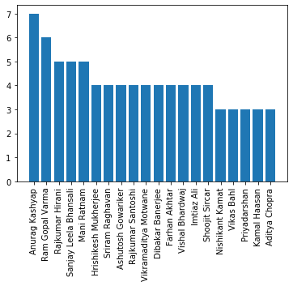

```python
plt.bar(director_freq.keys(), director_freq.values())
plt.xticks(rotation='vertical')
plt.show()
```

Looks like *Anurag Kashyap* is critically the most popular director (the views strongly correlate with that of IMDB audience). A similar histogram can be plotted for Writers and Actors. Here is a list of top writers:

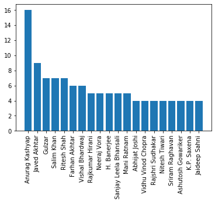

```python
writer_freq = {k: v for k,v in sorted(get_crew_freq(crew_type="writers").items(), key=lambda x: x[1], reverse=True)[:LIMIT]}
plt.bar(writer_freq.keys(), writer_freq.values())
plt.xticks(rotation='vertical')
plt.show()
```

It is suprising that *Anurag Kashyap* has topped this list as well! Let's experiment something else, we will try showing a correlation between top directors and top writers, the perfect recipe for success!

i.e we are finding which top directors and writers have collaborated with each other.

```python
top_directors = list(director_freq.keys())
top_writers = list(writer_freq.keys())

crew_corr = np.zeros(shape=(len(top_directors), len(top_writers)))

def fill_crew_corr(crew_corr, top_directors, top_writers):
    top_imdb_ids = top_movies(df, limit=250)["imdb_id"].tolist()

    for imdb_id in top_imdb_ids:
        d_ids = crew_df[crew_df["imdb_id"] == imdb_id]["directors"].all()
        w_ids = crew_df[crew_df["imdb_id"] == imdb_id]["writers"].all()

        directors = [director_df[director_df["crew_id"] == d_id]["name"].all() for d_id in d_ids]
        writers = [writer_df[writer_df["crew_id"] == w_id]["name"].all() for w_id in w_ids]

        for director in directors:
            for writer in writers:
                if writer in top_writers and director in top_directors:
                    crew_corr[top_writers.index(writer)][top_directors.index(director)] += 1

    return crew_corr

crew_corr = fill_crew_corr(crew_corr, top_directors, top_writers)
```

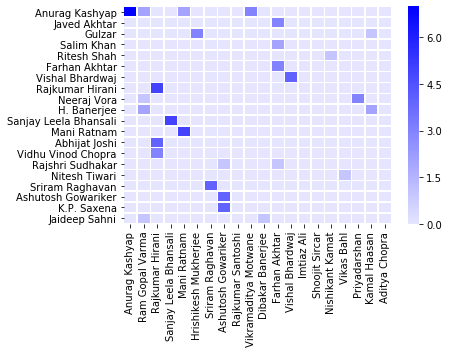

```python
cmap = sns.light_palette("Blue", as_cmap=True)

sns.heatmap(crew_corr, xticklabels=top_directors, yticklabels=top_writers, linewidth=0.5, cmap=cmap)
```

The heatmap is mostly empty, but as we can observe some popular directors and writers frequently collaborate with each other! Let's further this analysis by creating a 4D model to compare relationship between top actors, writers and directors. To create a 4D model, we will need frequency of a (director, actor, writer) relationship (for each movie).

```python
relation_dwa = dict() # This dictionary will hold the frequency count of {(director, writer, actor): freq, ..}

def find_dwa_reln(relation_dwa, top_directors, top_writers):
    top_imdb_ids = top_movies(df, limit=250)["imdb_id"].tolist()

    for imdb_id in top_imdb_ids:
        d_ids = crew_df[crew_df["imdb_id"] == imdb_id]["directors"].all()
        w_ids = crew_df[crew_df["imdb_id"] == imdb_id]["writers"].all()

        all_actors = df[df["imdb_id"] == imdb_id]["actors"].all()

        directors = [director_df[director_df["crew_id"] == d_id]["name"].all() for d_id in d_ids]
        writers = [writer_df[writer_df["crew_id"] == w_id]["name"].all() for w_id in w_ids]

        for director in directors:
            for writer in writers:
                for actor in [actor for actor in all_actors if actor != ""]:
                        try:
                            relation_dwa[(director, writer, actor)] += 1
                        except:
                            relation_dwa[(director, writer, actor)] = 1

    return relation_dwa

relation_dwa = {k: v for k,v in sorted(find_dwa_reln(relation_dwa, top_directors, top_writers).items(), key=lambda x: x[1], reverse=True)[:40]}
```

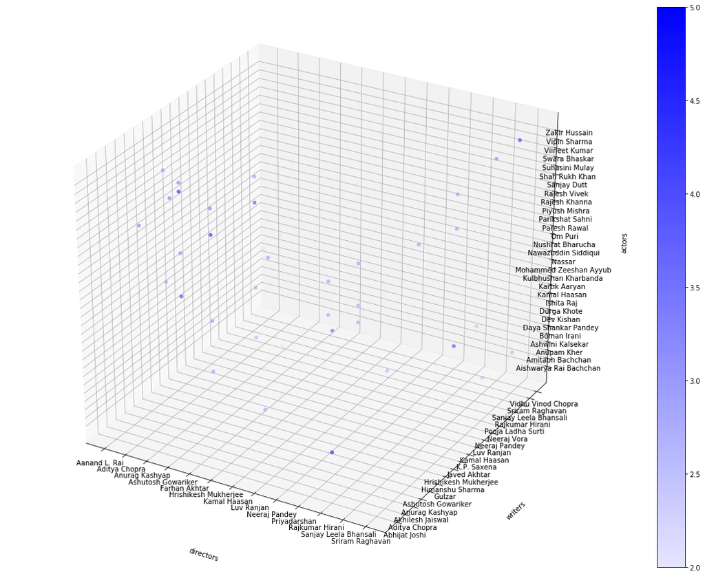

```python
Xuniques, X = np.unique([rel[0] for rel in relation_dwa], return_inverse=True)
Yuniques, Y = np.unique([rel[1] for rel in relation_dwa], return_inverse=True)
Zuniques, Z = np.unique([rel[2] for rel in relation_dwa], return_inverse=True)

fig = plt.figure(figsize=(20, 15))
ax = fig.add_subplot(111, projection='3d')

img = ax.scatter(X, Y, Z, c=[relation_dwa[rel] for rel in relation_dwa], cmap=cmap)
ax.set(xticks=range(len(Xuniques)), xticklabels=Xuniques,
       yticks=range(len(Yuniques)), yticklabels=Yuniques,
       zticks=range(len(Zuniques)), zticklabels=Zuniques)

ax.set_xlabel("directors"); ax.set_ylabel("writers"); ax.set_zlabel("actors");
ax.zaxis.labelpad = ax.xaxis.labelpad = ax.yaxis.labelpad = 50
plt.rcParams["axes.labelweight"] = "bold"

fig.colorbar(img)
plt.show()
```

Just like the heatmap, this model appears sparse! In the model above, the color scheme (`c`) acts as the fourth dimension (showing frequency).

## Content based filtering

We will now perform content based filtering using actors, director, writer, title, genres, story, summary and tagline (if any). For content based filtering the strategy we will follow is a trivial one. We will perform cosine similarity on the attributes mentioned above (after removing the stopwords and other minor cleaning). Getting director and writer info is being repeated frequently, so we will write a method for it.

```python
def get_director_writer(df, person="director"):
    if person == "director":
        d_ids = crew_df[crew_df["imdb_id"] == df["imdb_id"]]["directors"].all()
        directors = [director_df[director_df["crew_id"] == d_id]["name"].all() for d_id in d_ids]
        return directors
    elif person == "writer":
        w_ids = crew_df[crew_df["imdb_id"] == df["imdb_id"]]["writers"].all()
        writers = [writer_df[writer_df["crew_id"] == w_id]["name"].all() for w_id in w_ids]
        return writers
```

```python
def content_based(title, df, limit, offset):
    df["desc"] = df["original_title"].fillna("").apply(lambda x: x.lower()) + df["story"].fillna("").apply(lambda x: x.lower()) + df["summary"].fillna("").apply(lambda x: x.lower()) + df["tagline"].fillna("").apply(lambda x: x.lower()) + df["genres"].apply(lambda x: (" ".join(x)).lower())

    df["crew"] = df["actors"].fillna("").apply(lambda actors: (" ".join([actor.replace(" ", "") for actor in actors[:5]])).lower())

    #Let's try guessing the title index!
    try:
        index = df.index[df["original_title"] == title][0]
    except:
        try:
            title = get_close_matches(title, [movie for movie in df["original_title"].tolist()])[0]
            index = df.index[df["original_title"] == title][0]
        except:
            return None

    df["directors"] = df.apply(get_director_writer, args=("director",), axis=1)
    df["writers"] = df.apply(get_director_writer, args=("writer",), axis=1)

    df["crew"] += " "+df["directors"].fillna("").apply(lambda direcs: (" ".join([direc.replace(" ", "") for direc in DIRECTOR_WT*direcs if isinstance(direc, bool) == False])).lower())
    df["crew"] += " "+df["writers"].fillna("").apply(lambda writers: (" ".join([writer.replace(" ", "") for writer in WRITER_WT*writers if isinstance(writer, bool) == False])).lower())
    tfidf = CountVectorizer(analyzer="word", stop_words=stopwords.words("english"), ngram_range=(1, 2))
    tfidf_mat = tfidf.fit_transform(df["desc"] + df["crew"])
    cosine_sim = cosine_similarity(tfidf_mat, tfidf_mat)

    rec_movie = cosine_sim[index]
    ids = rec_movie.argsort()[::-1][1 : limit]
    return top_movies(df.iloc[ids], percentile=0.2)[["original_title", "genres", "runtime", "imdb_rating", "imdb_votes", "year_of_release", "wins_nominations", "release_date"]]

# You can include director and writer's significance by increasing their weight
DIRECTOR_WT = 1
WRITER_WT = 1
content_df = content_based("MS Dhoni An untold story", df, 10, 0)
content_df["genres"] = content_df["genres"].apply(lambda x: ", ".join(x))
content_df
```

|  | original_title | genres | runtime | imdb_rating | imdb_votes | year_of_release | wins_nominations | release_date |
| --- | --- | --- | --- | --- | --- | --- | --- | --- |
| 1070 | Chak De! India | Drama, Family, Sport | 153.0 | 8.2 | 68421.0 | 2007 | 28 wins & 13 nominations | 10 August 2007 (India) |
| 1259 | Iqbal | Drama, Sport | 132.0 | 8.1 | 14864.0 | 2005 | 9 wins & 13 nominations | 20 January 2006 (USA) |
| 692 | Ferrari Ki Sawaari | Comedy, Drama, Family | 140.0 | 6.4 | 4693.0 | 2012 | 4 nominations | 15 June 2012 (India) |
| 1126 | Say Salaam India: 'Let's Bring the Cup Home' | Drama, Sport | NaN | 6.4 | 84.0 | 2007 | NaN | NaN |
| 749 | Patiala House | Drama, Sport | 140.0 | 5.6 | 8301.0 | 2011 | NaN | 11 February 2011 (India) |
| 1044 | Meerabai Not Out | Comedy, Drama, Romance | NaN | 4.0 | 86.0 | 2008 | NaN | NaN |
| 960 | Dil Bole Hadippa! | Comedy, Drama, Sport | 148.0 | 4.5 | 3528.0 | 2009 | NaN | 18 September 2009 (India) |

As you can see, our approach is able to predict cricket based films for *MS Dhoni: An Untold Story*. We are passing our results to the `top_movies` method we wrote earlier with a 0.2 percentile to remove the worst reviewed films. Also I have added `difflib`'s `get_close_matches` method to predict the movie which is closest to the film entered by the user. This is helpful in situations where one doesn't know the exact movie title!

Again, this is a very basic approach and many sophisticated approaches exist! You can also use `tags.csv`, `genome_tags.csv` and `genome_scores.csv`. From [TIMDB's documentation](https://github.com/pncnmnp/TIMDB):

> The genome-scores were available for very few movies (64 in total) from "Full" MovieLens dataset.

*Based on my observation, `tags.csv` has tags for 504 movies!* Therefore, if the movie is not very popular, your best bet would be to generate tags from summary, story and tagline.

## Collaborative Filtering

Let us conclude this exploration by performing basic collaborative filtering using `./collaborative/ratings.csv`

```python
def collaborative(m_id):
    df_coll = pd.read_csv(open("./collaborative/ratings.csv"))
    df_titles = pd.read_csv(open("./collaborative/titles.csv"))

    reader = Reader(rating_scale=(1, 5))
    sim_options = {"name": "pearson_baseline", "user_based": False}
    data = Dataset.load_from_df(df_coll[["user_id", "movie_id", "rating"]], reader)

    trainset = data.build_full_trainset()
    model = KNNBaseline(sim_options=sim_options)
    model.fit(trainset)

    inn_id = model.trainset.to_inner_iid(m_id)
    inn_id_neigh = model.get_neighbors(inn_id, k=10)

    titles = list()
    for movielens_id in inn_id_neigh:
        titles += [df_titles[df_titles["movie_id"] == model.trainset.to_raw_iid(movielens_id)]["title"].all()]

    return titles

# Here 157392 is the movie_id for the movie: Dangal (2016)
collaborative(167392)
```

```
Estimating biases using als...
Computing the pearson_baseline similarity matrix...
Done computing similarity matrix.
```

```
['3 Idiots (2009)',
 'Chak De India! (2007)',
 'Like Stars on Earth (Taare Zameen Par) (2007)',
 'Paint It Yellow (Rang De Basanti) (2006)',
 'Children of Heaven  The (Bacheha-Ye Aseman) (1997)',
 'Munna bhai M.B.B.S. (2003)',
 'Queen (2014)',
 'Andaz Apna Apna (1994)',
 'Swades: We  the People (Our Country) (2004)',
 'Sholay (1975)']
```

From above you can see, we are being recommended movies with *Aamir Khan* in them. Also *sports* based movies and movies with the theme - *struggle* are popular. You can use `./collaborative/links.csv` to convert a `movie_id` to it's equivalent `imdb_id` and get the statistics for the same from `./1950-2019/bollywood_full.csv`. From the documentation:

> The leading zeros are removed for imdb_id, which are not removed for the rest of the database(i.e for "1950-1989", "1990-2009", "2010-2019" and "1950-2019").  
> **Example:** in links.csv if imdb_id is 123456, it can be tt0123456 in imdb_id col in the datasets in "1950-1989", "1990-2009" and "2010-2019".

So this is it! Hopefully I have given you a good overview of how this dataset looks like and what basic operations you can perform with it. **Try caching the models and dataframes to perform quick recommendations.** You can try and create a hybrid approach which combines results from content-based and collaborative filtering approaches. If you have any questions, you can contact me.

Keep exploring! 😄